# Basic interval operations for *GRanges* objects

There are many functions for manipulating *GRanges* objects. The functions can be classified as *intra-range functions*, *inter-range functions*, and *between-range functions*.

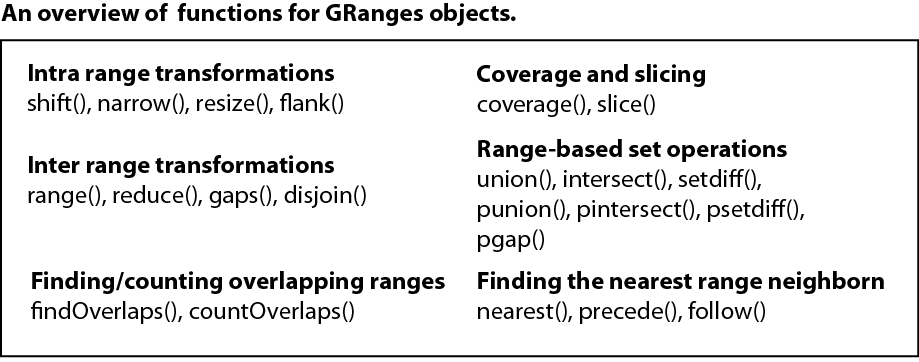

**Intra-range functions** operate on each element of a *GRanges* object independent of the other ranges in the object.

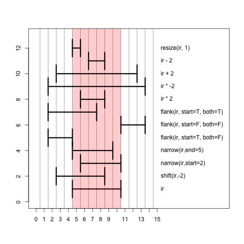

For example, the `flank` function can be used to recover regions flanking the set of ranges represented by the *GRanges* object. So to get a *GRanges* object containing the ranges that include the 10 bases upstream according to the direction of “transcription” (indicated by the strand):

```r
g <- gr[1:3]
g <- append(g, gr[10])
flank(g, 10)
```

```
## GRanges object with 4 ranges and 2 metadata columns:
##     seqnames    ranges strand |     score                GC
##        <Rle> <IRanges>  <Rle> | <integer>         <numeric>
##   a     chr1   105-114      - |         1                 1
##   b     chr2    95-104      + |         2 0.888888888888889
##   c     chr2   115-124      + |         3 0.777777777777778
##   j     chr3   191-200      - |        10                 0
##   -------
##   seqinfo: 455 sequences (1 circular) from hg38 genome
```

And to include the downstream bases:

```r
flank(g, 10, start=FALSE)
```

```
## GRanges object with 4 ranges and 2 metadata columns:
##     seqnames    ranges strand |     score                GC
##        <Rle> <IRanges>  <Rle> | <integer>         <numeric>
##   a     chr1    91-100      - |         1                 1
##   b     chr2   121-130      + |         2 0.888888888888889
##   c     chr2   134-143      + |         3 0.777777777777778
##   j     chr3   160-169      - |        10                 0
##   -------
##   seqinfo: 455 sequences (1 circular) from hg38 genome
```

A common use case for `flank()` is generating promoter regions based on the transcript ranges. There is a convenience function that generates a region starting a defined number of bp upstream and downstream of the TSS.

```r
promoters(g, upstream=100, downstream=0)
```

```
## GRanges object with 4 ranges and 2 metadata columns:
##     seqnames    ranges strand |     score                GC
##        <Rle> <IRanges>  <Rle> | <integer>         <numeric>
##   a     chr1   105-204      - |         1                 1
##   b     chr2     5-104      + |         2 0.888888888888889
##   c     chr2    25-124      + |         3 0.777777777777778
##   j     chr3   191-290      - |        10                 0
##   -------
##   seqinfo: 455 sequences (1 circular) from hg38 genome
```

To ignore strand/transcription and assume the orientation of left to right use `unstrand()`,

```r
flank(unstrand(g), 10)
```

```
## GRanges object with 4 ranges and 2 metadata columns:
##     seqnames    ranges strand |     score                GC
##        <Rle> <IRanges>  <Rle> | <integer>         <numeric>
##   a     chr1    91-100      * |         1                 1
##   b     chr2    95-104      * |         2 0.888888888888889
##   c     chr2   115-124      * |         3 0.777777777777778
##   j     chr3   160-169      * |        10                 0
##   -------
##   seqinfo: 455 sequences (1 circular) from hg38 genome
```

Other examples of intra-range functions include `resize()` and `shift()`. The `shift()` function will move the ranges by a specific number of base pairs, and the `resize()` function will set a specific width, by default fixing the “transcription” start (or just the start when strand is “*“). The `fix=` argument controls whether the”start“,”end" or “center” is held constant.

```r
shift(g, 5)
```

```
## GRanges object with 4 ranges and 2 metadata columns:
##     seqnames    ranges strand |     score                GC
##        <Rle> <IRanges>  <Rle> | <integer>         <numeric>
##   a     chr1   106-109      - |         1                 1
##   b     chr2   110-125      + |         2 0.888888888888889
##   c     chr2   130-138      + |         3 0.777777777777778
##   j     chr3   175-195      - |        10                 0
##   -------
##   seqinfo: 455 sequences (1 circular) from hg38 genome
```

```r
resize(g, 30)
```

```
## GRanges object with 4 ranges and 2 metadata columns:
##     seqnames    ranges strand |     score                GC
##        <Rle> <IRanges>  <Rle> | <integer>         <numeric>
##   a     chr1    75-104      - |         1                 1
##   b     chr2   105-134      + |         2 0.888888888888889
##   c     chr2   125-154      + |         3 0.777777777777778
##   j     chr3   161-190      - |        10                 0
##   -------
##   seqinfo: 455 sequences (1 circular) from hg38 genome
```

The *GenomicRanges* help page `?"intra-range-methods"` summarizes these methods.

**Inter-range functions** involve comparisons between ranges in a single *GRanges* object and typically aggregate ranges.

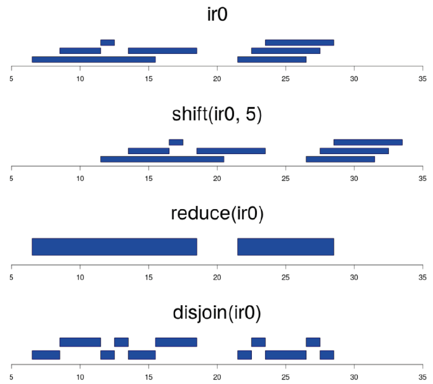

For instance, the `reduce()` function will merge overlapping and adjacent ranges to produce a minimal set of ranges representing the regions covered by the original set.

```r
reduce(gr)
```

```
## GRanges object with 8 ranges and 0 metadata columns:
##       seqnames    ranges strand
##          <Rle> <IRanges>  <Rle>
##   [1]     chr1   152-154      +
##   [2]     chr1   101-104      -
##   [3]     chr1   134-155      *
##   [4]     chr2   105-120      +
##   [5]     chr2   125-133      +
##   [6]     chr2       132      *
##   [7]     chr3   153-166      +
##   [8]     chr3   166-190      -
##   -------
##   seqinfo: 455 sequences (1 circular) from hg38 genome
```

```r
reduce(gr, ignore.strand=TRUE)
```

```
## GRanges object with 5 ranges and 0 metadata columns:
##       seqnames    ranges strand
##          <Rle> <IRanges>  <Rle>
##   [1]     chr1   101-104      *
##   [2]     chr1   134-155      *
##   [3]     chr2   105-120      *
##   [4]     chr2   125-133      *
##   [5]     chr3   153-190      *
##   -------
##   seqinfo: 455 sequences (1 circular) from hg38 genome
```

Rarely, it useful to complement the (reduced) ranges. Note that the universe is taken as the entire sequence span in all three strands (+, -, *), which is often surprising when working with unstranded ranges.

```r
gaps(g)
```

```
## GRanges object with 1369 ranges and 0 metadata columns:
##                  seqnames        ranges strand
##                     <Rle>     <IRanges>  <Rle>
##      [1]             chr1   1-248956422      +
##      [2]             chr1         1-100      -
##      [3]             chr1 105-248956422      -
##      [4]             chr1   1-248956422      *
##      [5]             chr2         1-104      +
##      ...              ...           ...    ...
##   [1365] chrUn_KI270756v1       1-79590      -
##   [1366] chrUn_KI270756v1       1-79590      *
##   [1367] chrUn_KI270757v1       1-71251      +
##   [1368] chrUn_KI270757v1       1-71251      -
##   [1369] chrUn_KI270757v1       1-71251      *
##   -------
##   seqinfo: 455 sequences (1 circular) from hg38 genome
```

The `disjoin` function breaks up the ranges so that they do not overlap but still cover the same regions:

```r
disjoin(g)
```

```
## GRanges object with 4 ranges and 0 metadata columns:
##       seqnames    ranges strand
##          <Rle> <IRanges>  <Rle>
##   [1]     chr1   101-104      -
##   [2]     chr2   105-120      +
##   [3]     chr2   125-133      +
##   [4]     chr3   170-190      -
##   -------
##   seqinfo: 455 sequences (1 circular) from hg38 genome
```

The `coverage` function counts how many ranges overlap each position in the sequence universe of a *GRanges* object.

```r
cov <- coverage(g)
cov[1:3]
```

```
## RleList of length 3
## $chr1
## integer-Rle of length 248956422 with 3 runs
##   Lengths:       100         4 248956318
##   Values :         0         1         0
##
## $chr2
## integer-Rle of length 242193529 with 5 runs
##   Lengths:       104        16         4         9 242193396
##   Values :         0         1         0         1         0
##
## $chr3
## integer-Rle of length 198295559 with 3 runs
##   Lengths:       169        21 198295369
##   Values :         0         1         0
```

The coverage is stored compactly as an *RleList*, with one *Rle* vector per sequence. We can convert it to a *GRanges*,

```r
cov_gr <- GRanges(cov)
cov_gr
```

```
## GRanges object with 463 ranges and 1 metadata column:
##                 seqnames        ranges strand |     score
##                    <Rle>     <IRanges>  <Rle> | <integer>
##     [1]             chr1         1-100      * |         0
##     [2]             chr1       101-104      * |         1
##     [3]             chr1 105-248956422      * |         0
##     [4]             chr2         1-104      * |         0
##     [5]             chr2       105-120      * |         1
##     ...              ...           ...    ... .       ...
##   [459] chrUn_KI270753v1       1-62944      * |         0
##   [460] chrUn_KI270754v1       1-40191      * |         0
##   [461] chrUn_KI270755v1       1-36723      * |         0
##   [462] chrUn_KI270756v1       1-79590      * |         0
##   [463] chrUn_KI270757v1       1-71251      * |         0
##   -------
##   seqinfo: 455 sequences from an unspecified genome
```

and even convert the *GRanges* form back to an *RleList* by computing a weighted coverage,

```r
cov <- coverage(cov_gr, weight="score")
```

The *GRanges* derivative *GPos*, a compact representation of width 1 ranges, is useful for representing coverage, although it cannot yet represent the coverage for the entire human genome (or any genome with over ~ 2 billion bp).

```r
GPos(cov[1:3])
```

```
## GPos object with 689445510 positions and 0 metadata columns:
##               seqnames       pos strand
##                  <Rle> <integer>  <Rle>
##           [1]     chr1         1      *
##           [2]     chr1         2      *
##           [3]     chr1         3      *
##           [4]     chr1         4      *
##           [5]     chr1         5      *
##           ...      ...       ...    ...
##   [689445506]     chr3 198295555      *
##   [689445507]     chr3 198295556      *
##   [689445508]     chr3 198295557      *
##   [689445509]     chr3 198295558      *
##   [689445510]     chr3 198295559      *
##   -------
##   seqinfo: 3 sequences from an unspecified genome
```

These inter-range functions all generate entirely new sets of ranges. The return value is left unannotated, since there is no obvious way to carry the metadata across the operation. The user is left to map the metadata to the new ranges. Functions like `reduce()` and `disjoin()` facilitate this by optionally including in the returned metadata a one-to-many reverse mapping from the aggregate ranges to input ranges. For example, to average the score over a reduction,

```r
rg <- reduce(gr, with.revmap=TRUE)
rg$score <- mean(extractList(gr$score, rg$revmap))
```

See the *GenomicRanges* help page `?"inter-range-methods"` for additional help.

## Interval set operations for *GRanges* objects

**Between-range functions** calculate relationships between different *GRanges* objects. Of central importance are `findOverlaps` and related operations; these are discussed below. Additional operations treat *GRanges* as mathematical sets of coordinates; `union(g, g2)` is the union of the coordinates in `g` and `g2`. Here are examples for calculating the `union`, the `intersect` and the asymmetric difference (using `setdiff`).

```r
g2 <- head(gr, n=2)
union(g, g2)
```

```
## GRanges object with 4 ranges and 0 metadata columns:
##       seqnames    ranges strand
##          <Rle> <IRanges>  <Rle>
##   [1]     chr1   101-104      -
##   [2]     chr2   105-120      +
##   [3]     chr2   125-133      +
##   [4]     chr3   170-190      -
##   -------
##   seqinfo: 455 sequences (1 circular) from hg38 genome
```

```r
intersect(g, g2)
```

```
## GRanges object with 2 ranges and 0 metadata columns:
##       seqnames    ranges strand
##          <Rle> <IRanges>  <Rle>
##   [1]     chr1   101-104      -
##   [2]     chr2   105-120      +
##   -------
##   seqinfo: 455 sequences (1 circular) from hg38 genome
```

```r
setdiff(g, g2)
```

```
## GRanges object with 2 ranges and 0 metadata columns:
##       seqnames    ranges strand
##          <Rle> <IRanges>  <Rle>
##   [1]     chr2   125-133      +
##   [2]     chr3   170-190      -
##   -------
##   seqinfo: 455 sequences (1 circular) from hg38 genome
```

Related functions are available when the structure of the *GRanges* objects are ‘parallel’ to one another, i.e., element 1 of object 1 is related to element 1 of object 2, and so on. These operations all begin with a `p`, which is short for parallel. The functions then perform element-wise, e.g., the union of element 1 of object 1 with element 1 of object 2, etc. A requirement for these operations is that the number of elements in each *GRanges* object is the same, and that both of the objects have the same seqnames and strand assignments throughout.

```r
g3 <- g[1:2]
ranges(g3[1]) <- IRanges(start=105, end=112)
punion(g2, g3)
```

```
## GRanges object with 2 ranges and 0 metadata columns:
##     seqnames    ranges strand
##        <Rle> <IRanges>  <Rle>
##   a     chr1   101-112      -
##   b     chr2   105-120      +
##   -------
##   seqinfo: 455 sequences (1 circular) from hg38 genome
```

```r
pintersect(g2, g3)
```

```
## GRanges object with 2 ranges and 3 metadata columns:
##     seqnames    ranges strand |     score                GC       hit
##        <Rle> <IRanges>  <Rle> | <integer>         <numeric> <logical>
##   a     chr1   105-104      - |         1                 1      TRUE
##   b     chr2   105-120      + |         2 0.888888888888889      TRUE
##   -------
##   seqinfo: 455 sequences (1 circular) from hg38 genome
```

```r
psetdiff(g2, g3)
```

```
## GRanges object with 2 ranges and 0 metadata columns:
##     seqnames    ranges strand
##        <Rle> <IRanges>  <Rle>
##   a     chr1   101-104      -
##   b     chr2   105-104      +
##   -------
##   seqinfo: 455 sequences (1 circular) from hg38 genome
```

For more information on the `GRanges` classes be sure to consult the manual page.

```r
?GRanges
```

A relatively comprehensive list of available functions is discovered with

```r
methods(class="GRanges")
```

## Exercises (10 min)

1. Generate a `GRanges` object that contains the promoters for all genes on chromosome 22 of the human `hg38` genome assembly. The promoter sequence should only contain the 1 kbp upstream region of each gene.
2. Reduce the set of promoters to a non-overlapping set of promoters.
3. Compare the gene coordinates of the human `hg19` and `hg38` genome assemblies on chromosome 22. Therefore, subset to genes on chromosome 22 that are annotated for both genome assemblies. Then, use `ranges` to extract the gene coordinates, and compute pairwise intersections between them. For how many genes is the intersection larger than zero?